# Numerical Integration

C14026175 李奇軒 & C14026214 曾敬珊

```r
# Initial
# Get Data
url <- "https://drive.google.com/uc?authuser=0&id=1cm5peMNKu1uEdtoqlWt_bLi5l3cvb8SQ&export=download"
data <- read.csv(url, header = F)

if (!"magick" %in% installed.packages()) install.packages("magick")
library(magick)

# Reorganize
col_names <- c("h","M_Time","M_Value","M_Error","T_Time","T_Value","T_Error",
               "S_Time","S_Value","S_Error","M_Digit","T_Digit","S_Digit")

# Set Digits
data[,1] <- 1:15
data[,11] <- -trunc(log10(data[,4]))
data[,12] <- -trunc(log10(data[,7]))
data[,13] <- -trunc(log10(data[,10]))

# Reset Names
colnames(data) <- col_names

attach(data)

# Define fx
fx <- function(x){
  2*x + x * sin(x)
  }
```

### Introduction

Not all functions can be evaluated by the *Fundamental Theorem of Calculus* .  
$\begin{align*} \text{Example : }\large x^x \ \text{or} \ \frac{sin(x)}{x} \large \\ \end{align*}$  
- **Liouville’s theorem**

Therefore, we need to use **Numerical Integration** to approximate the value of this kind function.

### Methods

**Numerical Integration** methods can generally be described as combining evaluations of the **Integrand** to get an approximation to the integral.  
The **Integrand** is evaluated at a finite set of points called **Integration Points** and a weighted sum of these values is used to approximate the integral.  
The **Integration Points** and weights depend on the specific method used and the accuracy required from the approximation.

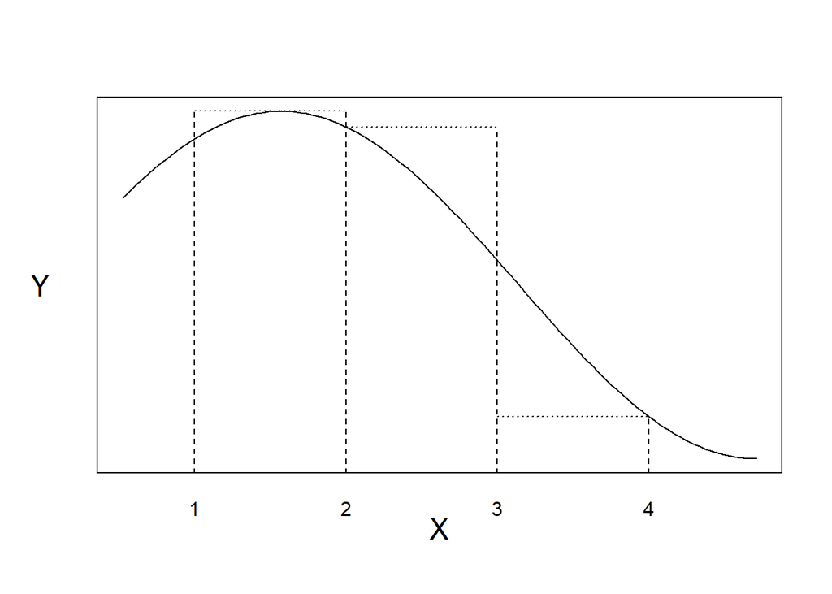

```r
plot(sin, from = pi/6, to = 3*pi/2,xlab = "", ylab = "", xaxt = 'n', yaxt = 'n')
axis(1, at=1:4, tck = 0)
mtext("X", side = 1, cex = 1.5, line = 2)
mtext("Y", side = 2, cex = 1.5, line = 2, las = 1)

lines(c(1,1), c(-1.2, max(sin(1:100/50))), lty = 2)
lines(c(2,2), c(-1.2, max(sin(1:100/50))), lty = 2)
lines(c(3,3), c(-1.2, sin(2)), lty = 2)
lines(c(4,4), c(-1.2, sin(4)), lty = 2)

lines(c(1,2), c(max(sin(1:100/50)), max(sin(1:100/50))), lty = 3)
lines(c(2,3), c(sin(2), sin(2)), lty = 3)
lines(c(3,4), c(sin(4), sin(4)), lty = 3)
```

- **Midpoint Rule**
- **Trapezoidal Rule**
- *Simpson’s* Rule

### Consider the function $\int_{5}^{13} 2x + xsin(x) dx$

[figure not shown]

```r
plot(fx, from = 4.5, to = 13.5, xlab = "", ylab = "",
     xaxt = 'n', yaxt = 'n', col = "skyblue", lwd = 3)
title(expression(paste(integral(x + x*sin(x)*dx, 5, 13))),cex = 1.5)
axis(1, at=5:13)
mtext("X", side = 1, cex = 1.5, line = 2.5)
mtext("Y", side = 2, cex = 1.5, line = 2, las = 1)
```

### Midpoint Rule

The Midpoint Rule is a kind of Riemann sum, which working by approximating the region under the graph of the function as rectangles .

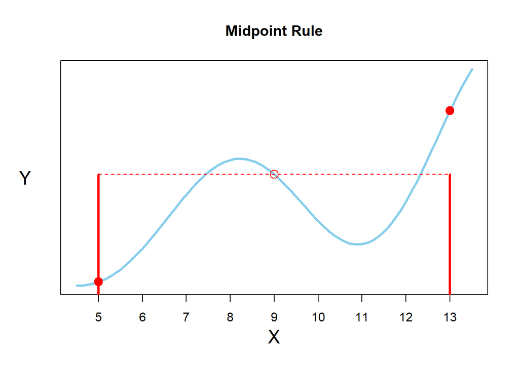

```r
plot(fx, from = 4.5, to = 13.5, xlab = "", ylab = "",
     xaxt = 'n', yaxt = 'n', col = "skyblue", lwd = 3,
     main = "Midpoint Rule")
axis(1, at=5:13)
mtext("X", side = 1, cex = 1.5, line = 2.5)
mtext("Y", side = 2, cex = 1.5, line = 2, las = 1)

points(5, fx(5), pch = 21 , bg = "red", cex = 1.5 , col = "red")
points(13, fx(13), pch = 21 , bg = "red", cex = 1.5, col = "red")
points(9,fx(9), cex = 1.5 , col = "red")

lines(c(5, 13), c(fx(9), fx(9)), col = "red" , lty = 2)
lines(c(5,5), c(0,fx(9)), col = "red", lwd = 3)
lines(c(13,13), c(0,fx(9)), col = "red", lwd = 3)
```

when h get smaller , we can see that the region get closer to the real value .

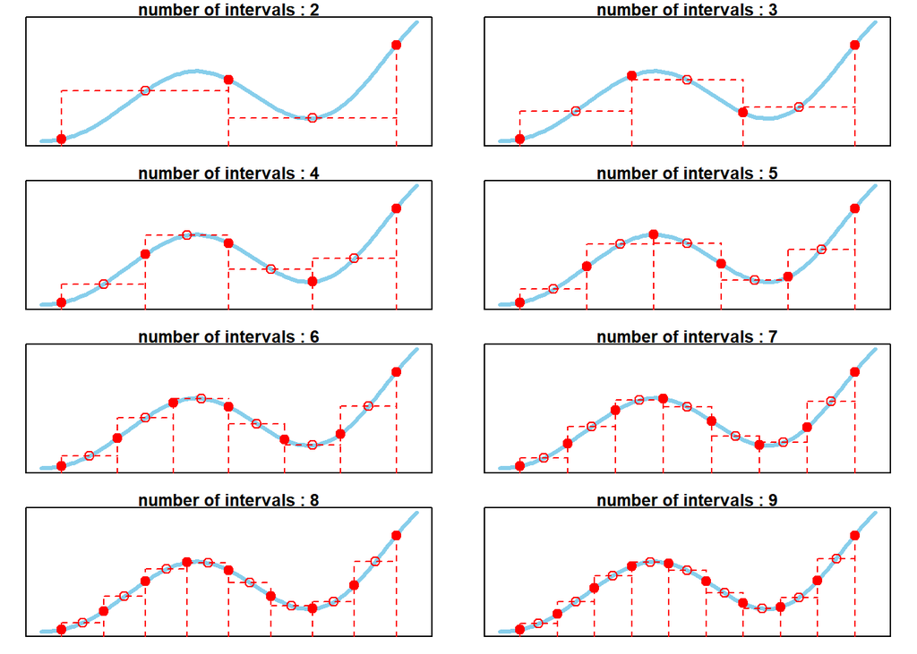

```r
par(mfrow = c(4, 2), mar=c(1,1.5,1,1.5))
pointNum = 8
for (n in c(3:(pointNum+2))){
  plot(fx, from = 4.5, to = 13.5, xlab = "", ylab = "",
       xaxt = 'n', yaxt = 'n', col = "skyblue", lwd = 3,
       main = paste(c("number of intervals : "), n-1, sep=""))
  for (i in c(1:n)){
    hs = 8/(n-1)
    px = 5 + hs * (i-1)
    py = fx(px)
    midx = px+hs/2
    midy = fx(px+hs/2)
    points(px, py, pch = 21 , bg = "red", cex = 1.5, col = "red")
    lines(c(px, px), c(0, py), col = "red", lty = 2, lwd =1)
    if(i<n){
      points(midx,midy, cex = 1.5 , col = "red")
      #lines(c(midx, midx), c(0, midy), col = "darkred", lty = 2, lwd = 0.3)
      lines(c(px, px + hs), c(midy, midy), col = "red", lwd = 1, lty = 2)
      lines(c(px, px), c(0, midy), col = "red", lty = 2)
      lines(c(px+hs, px+hs), c(0, midy), col = "red", lty = 2)
    }
  }
}
```

### Trapezoidal Rule

The Trapezoidal Rule works by approximating the region under the graph of the function as a trapezoid .

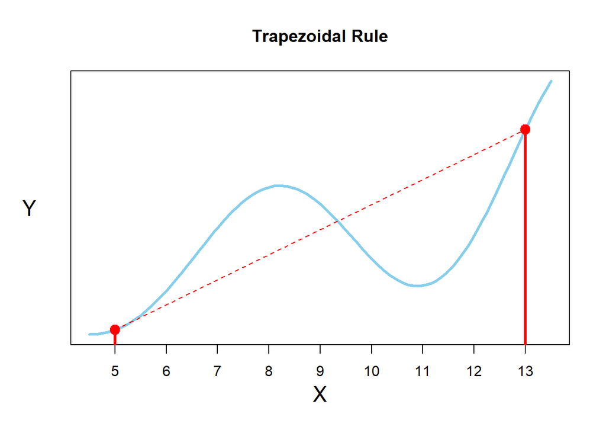

```r
plot(fx, from = 4.5, to = 13.5, xlab = "", ylab = "",
     xaxt = 'n', yaxt = 'n', col = "skyblue", lwd = 3,
     main = "Trapezoidal Rule")
axis(1, at=5:13)
mtext("X", side = 1, cex = 1.5, line = 2.5)
mtext("Y", side = 2, cex = 1.5, line = 2, las = 1)

points(5, fx(5), pch = 21 , bg = "red", cex = 1.5 , col = "red")
points(13, fx(13), pch = 21 , bg = "red", cex = 1.5, col = "red")

lines(c(5,13),c(fx(5),fx(13)), col = "red" , lty = 2)
lines(c(5,5), c(0,fx(5)), col = "red", lwd = 3)
lines(c(13,13), c(0,fx(13)), col = "red", lwd = 3)
```

when h get smaller , we can see that the region get closer to the real value .

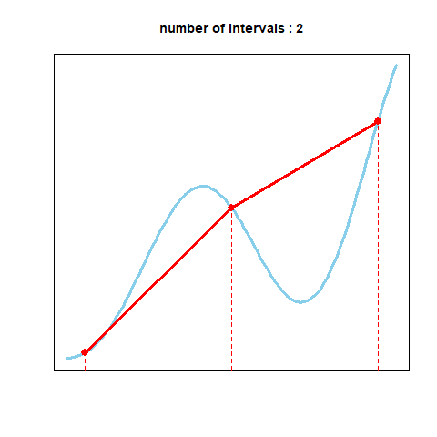

```r
pointNum = 15

for (n in c(3:(pointNum+2))){
  png(filename = paste(c("Trapezoidal Rule"), n-2, ".png", sep=""))
  plot(fx, from = 4.5, to = 13.5, xlab = "", ylab = "",
       xaxt = 'n', yaxt = 'n', col = "skyblue", lwd = 3,
       main = paste(c("number of intervals : "), n-1, sep=""))
  for (i in c(1:n)){
    hs = 8/(n-1)
    px = 5 + hs * (i-1)
    py = fx(px)
    points(px, py, pch = 21 , bg = "red", cex = 1.5, col = "red")
    lines(c(px, px), c(0, py), col = "red", lty = 2)
    if(i<n){
      lines(c(px, px + hs), c(py, fx(px + hs)), col = "red", lwd = 3)
    }
  }
  dev.off()
}
for(i in 1:pointNum ){
  assign( paste("PIC", i, sep = ""),
  image_read( paste( c("Trapezoidal Rule"), i, ".png", sep="")))
}
PIC <- c(PIC1,PIC2,PIC3,PIC4,PIC5,PIC6,PIC7,PIC8,PIC9,PIC10,PIC11,PIC12,PIC13,PIC14,PIC15)
animation <- image_animate(PIC, fps = 1)
animation
```

### Simpson’s Rule

Different to the above two rules ,using straight lines to model a curve . Simpson’s Rule use parabolas to approximate each part of the curve. This proved to be very efficient since it’s generally more accurate than the other numerical methods

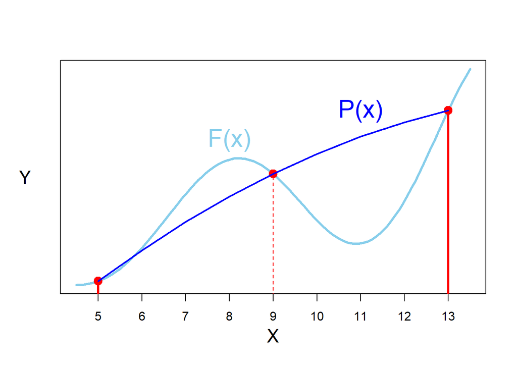

```r
plot(fx, from = 4.5, to = 13.5, xlab = "", ylab = "",
     xaxt = 'n', yaxt = 'n', col = "skyblue", lwd = 3)
axis(1, at=5:13)
mtext("X", side = 1, cex = 1.5, line = 2.5)
mtext("Y", side = 2, cex = 1.5, line = 2, las = 1)

points(5, fx(5), pch = 21 , bg = "red", cex = 1.5 , col = "red")
points(13, fx(13), pch = 21 , bg = "red", cex = 1.5, col = "red")
points(9,fx(9), pch = 21 , bg = "red", cex = 1.5, col = "red")

lines(c(5,5), c(0,fx(5)), col = "red", lwd = 3)
lines(c(9,9), c(0,fx(9)), col = "red", lty = 2)
lines(c(13,13), c(0,fx(13)), col = "red", lwd = 3)

# Define the parabola function
px <- function(x){
  fx(5)*(x-9)*(x-13)/(5-9)/(5-13)+fx(9)*(x-5)*(x-13)/(9-5)/(9-13)+fx(13)*(x-5)*(x-9)/(13-5)/(13-9)
}
lines(5:13/1, px(5:13/1), col = "blue", lwd = 2)
text(11, px(11) + 4, "P(x)", cex = 2, col = "blue")
text(8, fx(8) + 3, "F(x)", cex = 2, col = "skyblue")
```

when h get smaller , we can see that the region get closer to the real value .

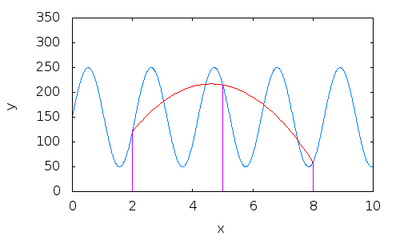

### Comparison

- Cost Time

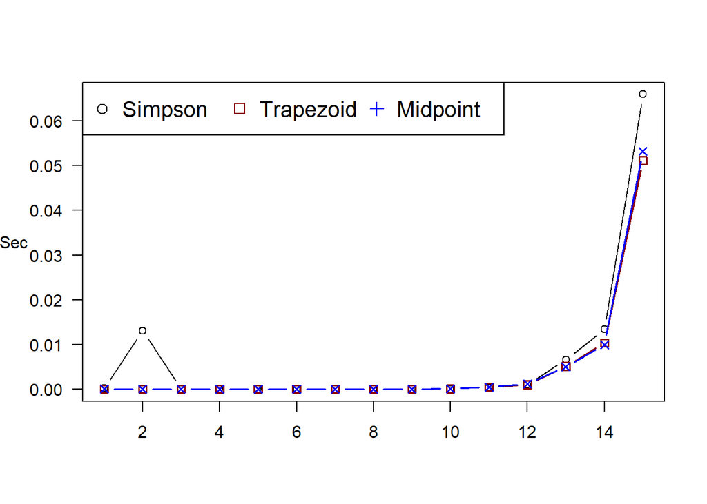

```r
plot(h, S_Time, pch = 1, type = "b",col = 1, xlab="", ylab="", las = 1)
mtext("Sec", side = 2, line = 2.7, las = 1)
points(h, T_Time, pch = 0, type = "b", col = "dark red", lwd = 1.5)
points(h, M_Time, pch = 4, type = "b", col = "blue", lwd = 1.5)
legend("topleft", legend = c("Simpson", "Trapezoid", "Midpoint"), col = c(1,"dark red","blue"),
       cex = 1.3, ncol = 3, pch = c(1,0,3))
```

- Error Rate

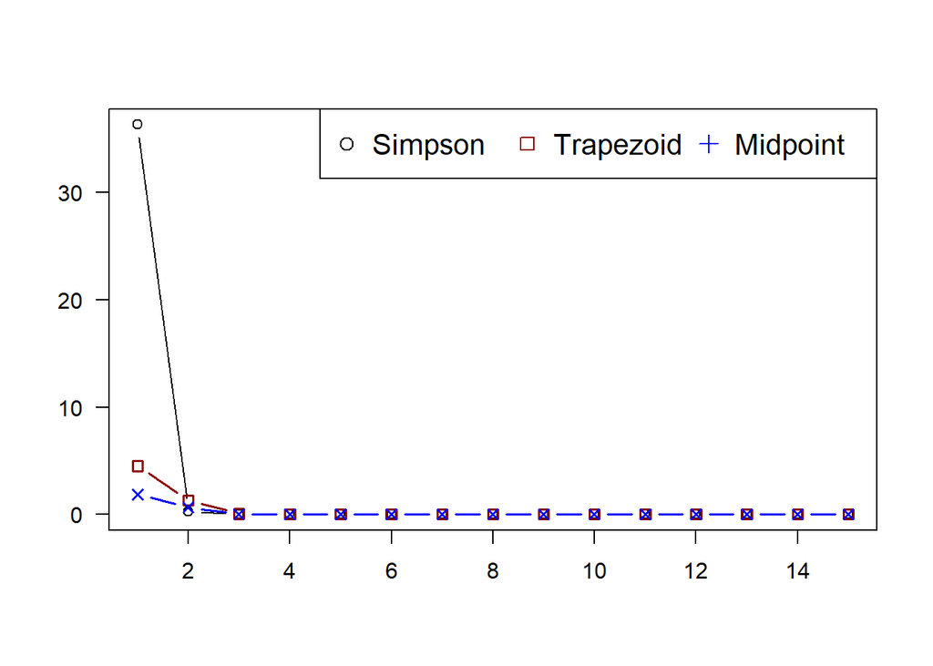

```r
plot(h, S_Error, pch = 1, type = "b",col = 1, xlab="", ylab="", las = 1)
points(h, T_Error, pch = 0, type = "b", col = "dark red", lwd = 1.5)
points(h, M_Error, pch = 4, type = "b", col = "blue", lwd = 1.5)
legend("topright", legend = c("Simpson", "Trapezoid", "Midpoint"), col = c(1,"dark red","blue"),
       cex = 1.3, ncol = 3, pch = c(1,0,3))
```

- Digits

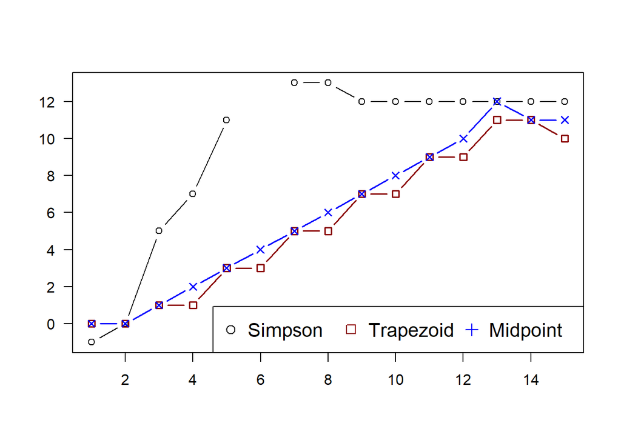

```r
plot(h, S_Digit, pch = 1, type = "b",col = 1, xlab="", ylab="", las = 1)
points(h, T_Digit, pch = 0, type = "b", col = "dark red", lwd = 1.5)
points(h, M_Digit, pch = 4, type = "b", col = "blue", lwd = 1.5)
legend("bottomright", legend = c("Simpson", "Trapezoid", "Midpoint"), col = c(1,"dark red","blue"),
       cex = 1.3, ncol = 3, pch = c(1,0,3))
```